# Boston Housing Data Set

This dataset contains information collected by the U.S Census Service concerning housing in the area of Boston Mass.

There are 13 attributes in each case of the dataset. They are:

1. CRIM - per capita crime rate by town
2. ZN - proportion of residential land zoned for lots over 25,000 sq.ft.
3. INDUS - proportion of non-retail business acres per town.
4. CHAS - Charles River dummy variable (1 if tract bounds river; 0 otherwise)
5. NOX - nitric oxides concentration (parts per 10 million)
6. RM - average number of rooms per dwelling
7. AGE - proportion of owner-occupied units built prior to 1940
8. DIS - weighted distances to five Boston employment centres
9. RAD - index of accessibility to radial highways
10. TAX - full-value property-tax rate per $10,000
11. PTRATIO - pupil-teacher ratio by town
12. B - 1000(Bk - 0.63)^2 where Bk is the proportion of blacks by town
13. LSTAT - % lower status of the population

Target variable is the Median Value/price of the owner occupied home

```python
# Importing the dataset
from sklearn.datasets import load_boston
load_data = load_boston()
X, y = load_boston(return_X_y=True)
print(X.shape)
```

```
(506, 13)
```

```python
feature_name = load_data['feature_names']
feature_name
```

```
array(['CRIM', 'ZN', 'INDUS', 'CHAS', 'NOX', 'RM', 'AGE', 'DIS', 'RAD',
       'TAX', 'PTRATIO', 'B', 'LSTAT'], dtype='<U7')
```

```python
# Adding the target variable name to the feaures
features = ['target']
features.extend(feature_name)
features
```

```
['target',
 'CRIM',
 'ZN',
 'INDUS',
 'CHAS',
 'NOX',
 'RM',
 'AGE',
 'DIS',
 'RAD',
 'TAX',
 'PTRATIO',
 'B',
 'LSTAT']
```

```python
# Checking the X and y variable
import pandas as pd
import numpy as np
boston_data = pd.DataFrame(data= np.c_[load_data['target'], load_data['data']],
                     columns= features )
```

```python
boston_data.head()
```

|  | target | CRIM | ZN | INDUS | CHAS | NOX | RM | AGE | DIS | RAD | TAX | PTRATIO | B | LSTAT |
| --- | --- | --- | --- | --- | --- | --- | --- | --- | --- | --- | --- | --- | --- | --- |
| 0 | 24.0 | 0.00632 | 18.0 | 2.31 | 0.0 | 0.538 | 6.575 | 65.2 | 4.0900 | 1.0 | 296.0 | 15.3 | 396.90 | 4.98 |
| 1 | 21.6 | 0.02731 | 0.0 | 7.07 | 0.0 | 0.469 | 6.421 | 78.9 | 4.9671 | 2.0 | 242.0 | 17.8 | 396.90 | 9.14 |
| 2 | 34.7 | 0.02729 | 0.0 | 7.07 | 0.0 | 0.469 | 7.185 | 61.1 | 4.9671 | 2.0 | 242.0 | 17.8 | 392.83 | 4.03 |
| 3 | 33.4 | 0.03237 | 0.0 | 2.18 | 0.0 | 0.458 | 6.998 | 45.8 | 6.0622 | 3.0 | 222.0 | 18.7 | 394.63 | 2.94 |
| 4 | 36.2 | 0.06905 | 0.0 | 2.18 | 0.0 | 0.458 | 7.147 | 54.2 | 6.0622 | 3.0 | 222.0 | 18.7 | 396.90 | 5.33 |

#### Step 1: Selecting the Important Variables

```python
# Selecting the Numerical Variables from the dataset: Removing the CHAS variable which is a categorical variable
boston_data1 = boston_data[['target', 'CRIM', 'ZN', 'INDUS', 'NOX', 'RM', 'AGE', 'DIS','RAD', 'TAX', 'PTRATIO', 'B', 'LSTAT']]
boston_data1.head()
```

|  | target | CRIM | ZN | INDUS | NOX | RM | AGE | DIS | RAD | TAX | PTRATIO | B | LSTAT |
| --- | --- | --- | --- | --- | --- | --- | --- | --- | --- | --- | --- | --- | --- |
| 0 | 24.0 | 0.00632 | 18.0 | 2.31 | 0.538 | 6.575 | 65.2 | 4.0900 | 1.0 | 296.0 | 15.3 | 396.90 | 4.98 |
| 1 | 21.6 | 0.02731 | 0.0 | 7.07 | 0.469 | 6.421 | 78.9 | 4.9671 | 2.0 | 242.0 | 17.8 | 396.90 | 9.14 |
| 2 | 34.7 | 0.02729 | 0.0 | 7.07 | 0.469 | 7.185 | 61.1 | 4.9671 | 2.0 | 242.0 | 17.8 | 392.83 | 4.03 |
| 3 | 33.4 | 0.03237 | 0.0 | 2.18 | 0.458 | 6.998 | 45.8 | 6.0622 | 3.0 | 222.0 | 18.7 | 394.63 | 2.94 |
| 4 | 36.2 | 0.06905 | 0.0 | 2.18 | 0.458 | 7.147 | 54.2 | 6.0622 | 3.0 | 222.0 | 18.7 | 396.90 | 5.33 |

```python
# Checking the Null Values if any
boston_data1.info()
```

```
<class 'pandas.core.frame.DataFrame'>
RangeIndex: 506 entries, 0 to 505
Data columns (total 13 columns):
 #   Column   Non-Null Count  Dtype
---  ------   --------------  -----
 0   target   506 non-null    float64
 1   CRIM     506 non-null    float64
 2   ZN       506 non-null    float64
 3   INDUS    506 non-null    float64
 4   NOX      506 non-null    float64
 5   RM       506 non-null    float64
 6   AGE      506 non-null    float64
 7   DIS      506 non-null    float64
 8   RAD      506 non-null    float64
 9   TAX      506 non-null    float64
 10  PTRATIO  506 non-null    float64
 11  B        506 non-null    float64
 12  LSTAT    506 non-null    float64
dtypes: float64(13)
memory usage: 51.5 KB
```

There are no Null values. We can go ahead with all the variables

```python
boston_data1.drop('target', axis = 1).columns
```

```
Index(['CRIM', 'ZN', 'INDUS', 'NOX', 'RM', 'AGE', 'DIS', 'RAD', 'TAX',
       'PTRATIO', 'B', 'LSTAT'],
      dtype='object')
```

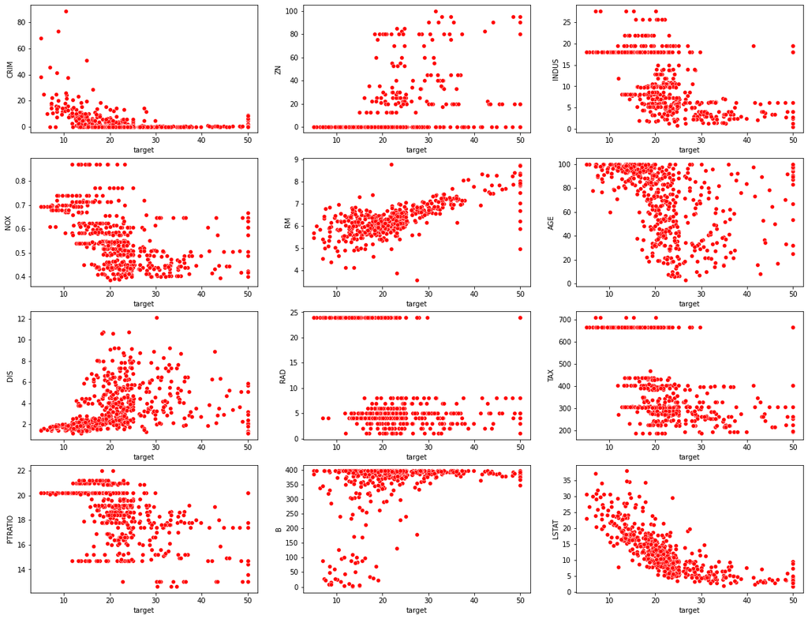

```python
# Plotting the graphs to see the relationship between the variables and the target variable
import matplotlib.pyplot as plt
from matplotlib.pyplot import figure

plt.figure(figsize=(20,40))

cols = boston_data1.drop('target', axis = 1).columns

for i in range(len(cols)):
    plt.subplot(10,3,i+1)
    sns.scatterplot(data=boston_data1, x="target", y=cols[i])
```

```python
# Checking the Correlation between the variables
# Finding the Correlation between the variables
cor_matrix = boston_data1.corr()

# Extracting the upper triangle as this is a symmetric matrix
upper_tri = cor_matrix.where(np.triu(np.ones(cor_matrix.shape),k=1).astype(np.bool))
upper_tri
```

|  | target | CRIM | ZN | INDUS | NOX | RM | AGE | DIS | RAD | TAX | PTRATIO | B | LSTAT |
| --- | --- | --- | --- | --- | --- | --- | --- | --- | --- | --- | --- | --- | --- |
| target | NaN | -0.388305 | 0.360445 | -0.483725 | -0.427321 | 0.695360 | -0.376955 | 0.249929 | -0.381626 | -0.468536 | -0.507787 | 0.333461 | -0.737663 |
| CRIM | NaN | NaN | -0.200469 | 0.406583 | 0.420972 | -0.219247 | 0.352734 | -0.379670 | 0.625505 | 0.582764 | 0.289946 | -0.385064 | 0.455621 |
| ZN | NaN | NaN | NaN | -0.533828 | -0.516604 | 0.311991 | -0.569537 | 0.664408 | -0.311948 | -0.314563 | -0.391679 | 0.175520 | -0.412995 |
| INDUS | NaN | NaN | NaN | NaN | 0.763651 | -0.391676 | 0.644779 | -0.708027 | 0.595129 | 0.720760 | 0.383248 | -0.356977 | 0.603800 |
| NOX | NaN | NaN | NaN | NaN | NaN | -0.302188 | 0.731470 | -0.769230 | 0.611441 | 0.668023 | 0.188933 | -0.380051 | 0.590879 |
| RM | NaN | NaN | NaN | NaN | NaN | NaN | -0.240265 | 0.205246 | -0.209847 | -0.292048 | -0.355501 | 0.128069 | -0.613808 |
| AGE | NaN | NaN | NaN | NaN | NaN | NaN | NaN | -0.747881 | 0.456022 | 0.506456 | 0.261515 | -0.273534 | 0.602339 |
| DIS | NaN | NaN | NaN | NaN | NaN | NaN | NaN | NaN | -0.494588 | -0.534432 | -0.232471 | 0.291512 | -0.496996 |
| RAD | NaN | NaN | NaN | NaN | NaN | NaN | NaN | NaN | NaN | 0.910228 | 0.464741 | -0.444413 | 0.488676 |
| TAX | NaN | NaN | NaN | NaN | NaN | NaN | NaN | NaN | NaN | NaN | 0.460853 | -0.441808 | 0.543993 |
| PTRATIO | NaN | NaN | NaN | NaN | NaN | NaN | NaN | NaN | NaN | NaN | NaN | -0.177383 | 0.374044 |
| B | NaN | NaN | NaN | NaN | NaN | NaN | NaN | NaN | NaN | NaN | NaN | NaN | -0.366087 |
| LSTAT | NaN | NaN | NaN | NaN | NaN | NaN | NaN | NaN | NaN | NaN | NaN | NaN | NaN |

```python
# Finding the Columns to drop which are highly correlated
to_drop = [column for column in upper_tri.columns if any(abs(upper_tri[column]) > 0.75)]
print(to_drop)
```

```
['NOX', 'DIS', 'TAX']
```

These three variables are highly correlated with the given variables:

1. NOX (nitric oxides concentration) is positvely correlated with INDUS(proportion of non-retail business acres per town), which makes sense because as the business rises the Nitric Oxide concentrantion would also rise
2. DIS (weighted distances to five Boston employment centres) is negatively correlated with NOX (nitric oxides concentration) which also makes sense because if the distance to employment centers is lower then there is more business nearby thus more pollution.
3. TAX(full-value property-tax rate) is highly positively correlated to RAD (index of accessibility to radial highways), again this makes sense because access to highway would make a property more valuable and thus the tax would also be higher.

```python
boston_data2 = boston_data1.drop(columns = ['NOX', 'DIS', 'TAX'], axis=1)
boston_data2.head()
```

|  | target | CRIM | ZN | INDUS | RM | AGE | RAD | PTRATIO | B | LSTAT |
| --- | --- | --- | --- | --- | --- | --- | --- | --- | --- | --- |
| 0 | 24.0 | 0.00632 | 18.0 | 2.31 | 6.575 | 65.2 | 1.0 | 15.3 | 396.90 | 4.98 |
| 1 | 21.6 | 0.02731 | 0.0 | 7.07 | 6.421 | 78.9 | 2.0 | 17.8 | 396.90 | 9.14 |
| 2 | 34.7 | 0.02729 | 0.0 | 7.07 | 7.185 | 61.1 | 2.0 | 17.8 | 392.83 | 4.03 |
| 3 | 33.4 | 0.03237 | 0.0 | 2.18 | 6.998 | 45.8 | 3.0 | 18.7 | 394.63 | 2.94 |
| 4 | 36.2 | 0.06905 | 0.0 | 2.18 | 7.147 | 54.2 | 3.0 | 18.7 | 396.90 | 5.33 |

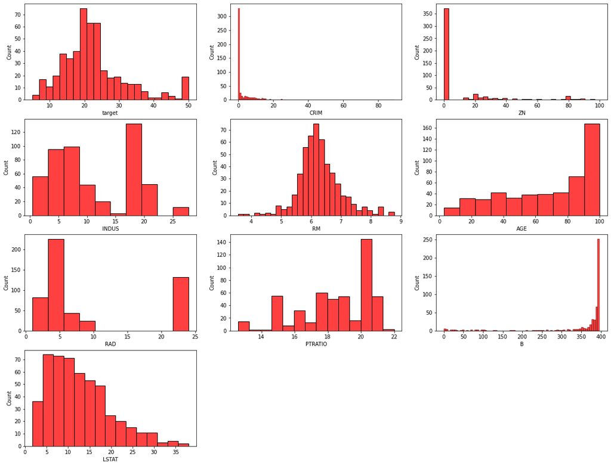

```python
# Checking the Distribution of the Variables
import matplotlib.pyplot as plt
from matplotlib.pyplot import figure

plt.figure(figsize=(20,40))

cols = boston_data2.columns

for i in range(len(cols)):
    plt.subplot(10,3,i+1)
    sns.histplot(boston_data2, x=cols[i])
```

From above graphs we see that we can drop following variables:

1. Rm: Its room available per dwelling. Its normally distributed, thus would not provide us much information.
2. B: % of Black people proportion as it racially discriminating factor.
3. ZN: As most of the values are zero in it.

```python
boston_data2 = boston_data1.drop(columns = ['RM', 'B', 'ZN'], axis=1)
boston_data2.head()
```

|  | target | CRIM | INDUS | NOX | AGE | DIS | RAD | TAX | PTRATIO | LSTAT |
| --- | --- | --- | --- | --- | --- | --- | --- | --- | --- | --- |
| 0 | 24.0 | 0.00632 | 2.31 | 0.538 | 65.2 | 4.0900 | 1.0 | 296.0 | 15.3 | 4.98 |
| 1 | 21.6 | 0.02731 | 7.07 | 0.469 | 78.9 | 4.9671 | 2.0 | 242.0 | 17.8 | 9.14 |
| 2 | 34.7 | 0.02729 | 7.07 | 0.469 | 61.1 | 4.9671 | 2.0 | 242.0 | 17.8 | 4.03 |
| 3 | 33.4 | 0.03237 | 2.18 | 0.458 | 45.8 | 6.0622 | 3.0 | 222.0 | 18.7 | 2.94 |
| 4 | 36.2 | 0.06905 | 2.18 | 0.458 | 54.2 | 6.0622 | 3.0 | 222.0 | 18.7 | 5.33 |

#### Step 2: Scaling the data using the Min Max Scaler

```python
from sklearn.preprocessing import MinMaxScaler
scaler = MinMaxScaler()

# Fitting the Scaler
scaler.fit(boston_data2)

# Transforming the Data using the above fitted scaler
scaled_data = scaler.transform(boston_data2)
scaled_data
```

```
array([[4.22222222e-01, 0.00000000e+00, 6.78152493e-02, ...,
        2.08015267e-01, 2.87234043e-01, 8.96799117e-02],
       [3.68888889e-01, 2.35922539e-04, 2.42302053e-01, ...,
        1.04961832e-01, 5.53191489e-01, 2.04470199e-01],
       [6.60000000e-01, 2.35697744e-04, 2.42302053e-01, ...,
        1.04961832e-01, 5.53191489e-01, 6.34657837e-02],
       ...,
       [4.20000000e-01, 6.11892474e-04, 4.20454545e-01, ...,
        1.64122137e-01, 8.93617021e-01, 1.07891832e-01],
       [3.77777778e-01, 1.16072990e-03, 4.20454545e-01, ...,
        1.64122137e-01, 8.93617021e-01, 1.31070640e-01],
       [1.53333333e-01, 4.61841693e-04, 4.20454545e-01, ...,
        1.64122137e-01, 8.93617021e-01, 1.69701987e-01]])
```

```python
# Converting the array into dataframe
scaled_df = pd.DataFrame(scaled_data, columns = [boston_data2.columns])
scaled_df.head()
```

|  | target | CRIM | INDUS | NOX | AGE | DIS | RAD | TAX | PTRATIO | LSTAT |
| --- | --- | --- | --- | --- | --- | --- | --- | --- | --- | --- |
| 0 | 0.422222 | 0.000000 | 0.067815 | 0.314815 | 0.641607 | 0.269203 | 0.000000 | 0.208015 | 0.287234 | 0.089680 |
| 1 | 0.368889 | 0.000236 | 0.242302 | 0.172840 | 0.782698 | 0.348962 | 0.043478 | 0.104962 | 0.553191 | 0.204470 |
| 2 | 0.660000 | 0.000236 | 0.242302 | 0.172840 | 0.599382 | 0.348962 | 0.043478 | 0.104962 | 0.553191 | 0.063466 |
| 3 | 0.631111 | 0.000293 | 0.063050 | 0.150206 | 0.441813 | 0.448545 | 0.086957 | 0.066794 | 0.648936 | 0.033389 |
| 4 | 0.693333 | 0.000705 | 0.063050 | 0.150206 | 0.528321 | 0.448545 | 0.086957 | 0.066794 | 0.648936 | 0.099338 |

#### Step 3 to 5 : Generating K Means for 2 to 10 clusters with 50-100 Random Starts and presenting the VAF. Then plotting the VAF and the scree plot to decide the number of clusters

```python
# Creating a Function to find R-Square for different clusters
from sklearn.cluster import KMeans
from sklearn.model_selection import train_test_split

def Kmeans_r_square(k):

    train, test = train_test_split(scaled_data, test_size=0.30, random_state=42)

    # Fitting a Model for K Means Clustering
    model_train = KMeans(n_clusters=k, n_init=100, max_iter=300, tol=0.0001, verbose=0, random_state = 13511).fit(train)

    # Predicting the Clusters
    model_train.fit_predict(train)

    # Printing the Centroids and Labels for clusters
    centroids = model_train.cluster_centers_
    train_labels = model_train.labels_

    # Finding the proportions of data in each cluster of train data
    train_proportions = ((np.bincount(train_labels)/len(train_labels))*100).round()

    # Creating a Matrix for the Centroids
    centroids_dataframe = pd.DataFrame(data=centroids)
    centroids_matrix = centroids_dataframe.values


    ########------Generating R-Square for train Data Set-------------------------------------------------------------------#######################

    # Creating a tuple of the length of the Cluster data and k cluster columns .
    shap = (len(train),k)

    # Creating a Matrix with k cluster columns and length of data. This will help us give a matrix showing that each data point belongs to which cluster.
    cluster_matrix = np.zeros(shap)

    # Assigning each data row into different clusters based on the cluster labels we got above
    for i in range(k):
        cluster_matrix[model_train.labels_ == i,i]=1.0

    # Finding the predicted data for each data point. By multiplying the Cluster Matrix (25*3 shape) and Centroids Matrix (3*7)
    predicted_data= np.dot(cluster_matrix,centroids_matrix)

    # Flatening the predicted_data array using .ravel. It will remove list within the list.
    predicted_data.ravel()
    train_data1 = train.ravel()

    # Finding the Pearson Correlation Coefficient between the predictied and the actual data and extracting the correlation between the two datas
    correlation = np.corrcoef(predicted_data.ravel(), train_data1.ravel())[0,1]

    # R-square is just the square of the Pearson Correlation Coefficient
    R_Square_train = ((correlation**2)*100).round(2)


    ####################---------Generating Test R-Square and Cluster Proportions using the Centroids from the train model-------##############################

    # Fixing the centroids_matrix as the start of the iterations for the test data and running just one iterations
    startpts = centroids_matrix
    test_model = KMeans(n_clusters=k, init=startpts, n_init = 1, max_iter=1, tol=0.0001, verbose=0, random_state = 13511).fit(test)

    # Extracting the labels and centroids of the test data and printing the proportions
    centroids_test = test_model.cluster_centers_
    test_labels = test_model.labels_

    # Creating a Matrix for the test Centroids
    centroids_test_dataframe = pd.DataFrame(data=centroids_test)
    centroids_test_matrix = centroids_test_dataframe.values

    # Finding the proportions of data in each cluster of test data using train centroids
    test_proportions = ((np.bincount(test_labels)/len(test_labels))*100).round()


    ##########---------------------------Test R-Square ----------------------------###########################

    # Creating a tuple of the length of the Cluster data and k cluster columns .
    shap = (len(test),k)

    # Creating a Matrix with k cluster columns and length of data. This will help us give a matrix showing that each data point belongs to which cluster.
    cluster_matrix_test = np.zeros(shap)

    # Assigning each data row into different clusters based on the cluster labels we got above
    for i in range(k):
        cluster_matrix_test[test_model.labels_ == i,i]=1.0

    # Finding the predicted data for each data point. By multiplying the Cluster Matrix (25*3 shape) and Centroids Matrix (3*7)
    predicted_data_test= np.dot(cluster_matrix_test,centroids_test_matrix)

    # Flatening the predicted_data array using .ravel. It will remove list within the list.
    predicted_data_test.ravel()
    test_data1 = test.ravel()

    # Finding the Pearson Correlation Coefficient between the predictied and the actual data and extracting the correlation between the two datas
    correlation_test = np.corrcoef(predicted_data_test.ravel(), test_data1.ravel())[0,1]

    # R-square is just the square of the Pearson Correlation Coefficient
    R_Square_test = ((correlation_test**2)*100).round(2)

    return R_Square_train,R_Square_test, train_proportions, test_proportions
```

```python
Kmeans_r_square(3)
```

```
(76.32, 80.13, array([45., 26., 30.]), array([44., 28., 28.]))
```

```python
train_r_square = []
test_r_square = []
train_proportions = []
test_proportions = []
K = range(2,11)
for k in K:
    train_r_square.append(Kmeans_r_square(k)[0])
    test_r_square.append(Kmeans_r_square(k)[1])
    train_proportions.append(Kmeans_r_square(k)[2])
    test_proportions.append(Kmeans_r_square(k)[3])
```

```python
KMeans_Results = pd.DataFrame()
KMeans_Results['Cluster_Size'] = range(2,11)
KMeans_Results['Train_RSquare'] = train_r_square
KMeans_Results['Test_RSquare'] = test_r_square
KMeans_Results['Train_Proportions'] = train_proportions
KMeans_Results['Test_Proportions'] = test_proportions
KMeans_Results
```

|  | Cluster_Size | Train_RSquare | Test_RSquare | Train_Proportions | Test_Proportions |
| --- | --- | --- | --- | --- | --- |
| 0 | 2 | 66.62 | 71.07 | [33.0, 67.0] | [34.0, 66.0] |
| 1 | 3 | 76.32 | 80.13 | [45.0, 26.0, 30.0] | [44.0, 28.0, 28.0] |
| 2 | 4 | 80.34 | 83.43 | [29.0, 25.0, 32.0, 13.0] | [32.0, 28.0, 32.0, 8.0] |
| 3 | 5 | 82.70 | 85.15 | [25.0, 30.0, 6.0, 11.0, 28.0] | [28.0, 29.0, 8.0, 8.0, 28.0] |
| 4 | 6 | 84.25 | 86.39 | [25.0, 28.0, 6.0, 5.0, 29.0, 6.0] | [28.0, 29.0, 6.0, 5.0, 30.0, 3.0] |
| 5 | 7 | 85.47 | 87.67 | [19.0, 25.0, 14.0, 25.0, 5.0, 6.0, 6.0] | [18.0, 28.0, 20.0, 19.0, 5.0, 3.0, 7.0] |
| 6 | 8 | 86.72 | 88.79 | [16.0, 16.0, 19.0, 6.0, 6.0, 10.0, 23.0, 5.0] | [20.0, 21.0, 18.0, 7.0, 3.0, 7.0, 19.0, 5.0] |
| 7 | 9 | 87.59 | 89.38 | [6.0, 16.0, 16.0, 14.0, 11.0, 17.0, 5.0, 9.0, ... | [3.0, 16.0, 21.0, 20.0, 7.0, 18.0, 5.0, 7.0, 3.0] |
| 8 | 10 | 88.44 | 89.68 | [18.0, 16.0, 3.0, 13.0, 9.0, 4.0, 14.0, 3.0, 5... | [20.0, 21.0, 3.0, 9.0, 7.0, 1.0, 12.0, 2.0, 5.... |

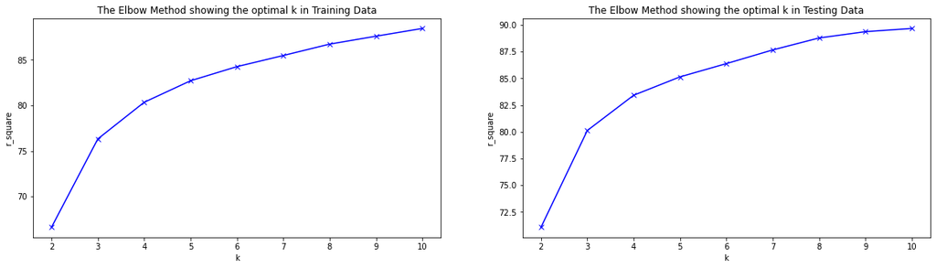

```python
# Plot the elbow
import matplotlib.pyplot as plt
from matplotlib.pyplot import figure
plt.figure(figsize=(20,5))

plt.subplot(1, 2, 1)
plt.plot(K, train_r_square, 'bx-')
plt.xlabel('k')
plt.ylabel('r_square')
plt.title('The Elbow Method showing the optimal k in Training Data')

plt.subplot(1, 2, 2)
plt.plot(K, test_r_square, 'bx-')
plt.xlabel('k')
plt.ylabel('r_square')
plt.title('The Elbow Method showing the optimal k in Testing Data')
```

##### Seeing the above elbow curves and the proportions from the KMeans results shows that 5 clusters are enough to explain the data set. Lets analyse the 5 clusters and check if business logic fits in or not

#### Analysing the K Means 5 Cluster

```python
# Running the Model with 5 clusters
k = 5
model = KMeans(n_clusters=k, n_init=100, max_iter=300, tol=0.0001, verbose=0, random_state = 13511).fit(scaled_data)

# Predicting the Clusters
model.fit_predict(scaled_data)

# Printing the Centroids and Labels for clusters
centroids = model.cluster_centers_
labels = model.labels_
```

```python
# Adding the labels to the original dataset
df = boston_data2.copy()
df['KM_label'] = labels
df.head()
```

|  | target | CRIM | INDUS | NOX | AGE | DIS | RAD | TAX | PTRATIO | LSTAT | KM_label |
| --- | --- | --- | --- | --- | --- | --- | --- | --- | --- | --- | --- |
| 0 | 24.0 | 0.00632 | 2.31 | 0.538 | 65.2 | 4.0900 | 1.0 | 296.0 | 15.3 | 4.98 | 0 |
| 1 | 21.6 | 0.02731 | 7.07 | 0.469 | 78.9 | 4.9671 | 2.0 | 242.0 | 17.8 | 9.14 | 3 |
| 2 | 34.7 | 0.02729 | 7.07 | 0.469 | 61.1 | 4.9671 | 2.0 | 242.0 | 17.8 | 4.03 | 4 |
| 3 | 33.4 | 0.03237 | 2.18 | 0.458 | 45.8 | 6.0622 | 3.0 | 222.0 | 18.7 | 2.94 | 4 |
| 4 | 36.2 | 0.06905 | 2.18 | 0.458 | 54.2 | 6.0622 | 3.0 | 222.0 | 18.7 | 5.33 | 4 |

```python
agg = df.groupby('KM_label', as_index = False).agg({
    'target':['mean'],
    'CRIM' : ['mean'],
    'INDUS': ['mean'],
    'AGE': ['mean'],
    'RAD': ['mean'],
    'LSTAT': ['mean']
}).round(1)
agg
```

|  | KM_label | target mean | CRIM mean | INDUS mean | AGE mean | RAD mean | LSTAT mean |
| --- | --- | --- | --- | --- | --- | --- | --- |
| 0 | 0 | 38.6 | 0.5 | 6.2 | 79.2 | 5.2 | 5.9 |
| 1 | 1 | 16.4 | 12.8 | 18.1 | 89.8 | 24.0 | 18.6 |
| 2 | 2 | 17.8 | 1.3 | 21.8 | 94.8 | 4.2 | 17.5 |
| 3 | 3 | 20.5 | 0.3 | 8.3 | 75.0 | 4.7 | 13.0 |
| 4 | 4 | 27.0 | 0.1 | 5.1 | 31.7 | 4.1 | 7.2 |

#### Step 7: Generating 3-5 Gaussian Mixtures

```python
from sklearn.mixture import GaussianMixture

def gaussian_mix(k):

    # Splitting into train and Test
    train, test = train_test_split(scaled_data, test_size=0.30, random_state=42)

    # Running the Model for train data set
    mymixture = GaussianMixture(n_components=k, n_init=100, max_iter = 200, random_state=13511)
    mixresults = mymixture.fit(train)

    # Storing the AIC and BIC information
    aic_train = mymixture.aic(train)
    bic_train = mymixture.bic(train)

    # Storing the means of Gaussian Mixtures
    train_mean = mymixture.means_

    # Storing the labels
    train_labels = mymixture.predict(train)

    # Finding the proportions of data in each cluster of train data
    train_proportions = ((np.bincount(train_labels)/len(train_labels))*100).round(2)

    ###############------------------Testing the Model---------------------####################################

    # Running the Gaussian Mixtures using the train means on the test dataset
    mymixture_test = GaussianMixture(n_components=k, n_init=1, means_init = train_mean,  random_state=13511)
    mixresults_test = mymixture_test.fit(test)

    # Storing the AIC and BIC information
    aic_test = mixresults_test.aic(test)
    bic_test = mixresults_test.bic(test)

    # Storing the means of Gaussian Mixtures
    test_mean = mixresults_test.means_

    # Storing the labels
    test_labels = mixresults_test.predict(test)

    # Finding the proportions of data in each cluster of train data
    test_proportions = ((np.bincount(test_labels)/len(test_labels))*100).round(2)


    return aic_train, bic_train, train_mean, train_proportions, aic_test, bic_test, test_mean, test_proportions
```

```python
gaussian_mix(2)
```

```
(-8243.618230289738,
 -7736.740334669214,
 array([[0.44128372, 0.00456579, 0.30903363, 0.27335759, 0.60144189,
         0.29677975, 0.1430799 , 0.25261549, 0.53555988, 0.24354019],
        [0.30060408, 0.1226708 , 0.5915713 , 0.55203983, 0.86689729,
         0.10070172, 0.91219963, 0.82765176, 0.77091527, 0.42043346]]),
 array([70.9, 29.1]),
 -4149.7790830703525,
 -3753.6507348394903,
 array([[0.41050505, 0.00347443, 0.29435817, 0.24330153, 0.57465593,
         0.3107465 , 0.14743083, 0.2417245 , 0.61286267, 0.25158037],
        [0.24444444, 0.15123875, 0.64662757, 0.58196159, 0.92322593,
         0.08568584, 1.        , 0.91412214, 0.80851064, 0.48585488]]),
 array([72.37, 27.63]))
```

```python
aic_train = []
bic_train = []
train_proportions = []
aic_test = []
bic_test = []
test_proportions = []

for i in range(3,6):
    aic_train.append(gaussian_mix(i)[0])
    bic_train.append(gaussian_mix(i)[1])
    train_proportions.append(gaussian_mix(i)[3])
    aic_test.append(gaussian_mix(i)[4])
    bic_test.append(gaussian_mix(i)[5])
    test_proportions.append(gaussian_mix(i)[7])
```

```python
GaussianM_Results = pd.DataFrame()
GaussianM_Results['Gaussian_Mixtures'] = range(3,6)
GaussianM_Results['Train_AIC'] = aic_train
GaussianM_Results['Test_AIC'] = aic_test
GaussianM_Results['Train_BIC'] = bic_train
GaussianM_Results['Test_BIC'] = bic_test
GaussianM_Results['Train_Proportions'] = train_proportions
GaussianM_Results['Test_Proportions'] = test_proportions
GaussianM_Results
```

|  | Gaussian_Mixtures | Train_AIC | Test_AIC | Train_BIC | Test_BIC | Train_Proportions | Test_Proportions |
| --- | --- | --- | --- | --- | --- | --- | --- |
| 0 | 3 | -10148.129903 | -3839.591392 | -9385.878411 | -3243.886929 | [55.37, 25.42, 19.21] | [69.74, 28.95, 1.32] |
| 1 | 4 | -11233.944383 | -4428.529932 | -10216.319295 | -3633.249355 | [25.42, 19.21, 44.92, 10.45] | [26.97, 0.0, 64.47, 8.55] |
| 2 | 5 | -12216.827300 | -4955.476663 | -10943.828615 | -3960.619972 | [38.7, 25.42, 5.37, 10.45, 20.06] | [38.82, 27.63, 4.61, 11.84, 17.11] |

##### From the above aic and bic information we choose model with 5 gaussian mixtures

#### Step 8 : Checking the Mean values and the interpretability of the results with 5 gaussian Mixtures

```python
# Running a Gaussian Mixture Model with 5 mixtures
mymixture = GaussianMixture(n_components=5, n_init=200, max_iter = 200, random_state=13511)
mixresults = mymixture.fit(scaled_data)
```

```python
# Storing the AIC and BIC information
aic = mymixture.aic(scaled_data)
bic = mymixture.bic(scaled_data)

# Storing the means of Gaussian Mixtures
mean = mymixture.means_

# Storing the labels
labels_GM = mymixture.predict(scaled_data)
```

```python
# Adding the labels to the original dataset
df['GM_label'] = labels_GM
df.head()
```

|  | target | CRIM | INDUS | NOX | AGE | DIS | RAD | TAX | PTRATIO | LSTAT | KM_label | GM_label |
| --- | --- | --- | --- | --- | --- | --- | --- | --- | --- | --- | --- | --- |
| 0 | 24.0 | 0.00632 | 2.31 | 0.538 | 65.2 | 4.0900 | 1.0 | 296.0 | 15.3 | 4.98 | 0 | 2 |
| 1 | 21.6 | 0.02731 | 7.07 | 0.469 | 78.9 | 4.9671 | 2.0 | 242.0 | 17.8 | 9.14 | 3 | 2 |
| 2 | 34.7 | 0.02729 | 7.07 | 0.469 | 61.1 | 4.9671 | 2.0 | 242.0 | 17.8 | 4.03 | 4 | 2 |
| 3 | 33.4 | 0.03237 | 2.18 | 0.458 | 45.8 | 6.0622 | 3.0 | 222.0 | 18.7 | 2.94 | 4 | 2 |
| 4 | 36.2 | 0.06905 | 2.18 | 0.458 | 54.2 | 6.0622 | 3.0 | 222.0 | 18.7 | 5.33 | 4 | 2 |

#### Step 9: Comparing the Clusters we got from K Means and Gaussian Mixtures

```python
# Comparing the Labels from the two types of clustering
df['Same_label'] = np.where(df['KM_label'] == df['GM_label'], True, False)

# Finding the total trues and false
df['Same_label'].value_counts()
```

```
False    364
True     142
Name: Same_label, dtype: int64
```

```python
agg_GM = df.groupby('GM_label', as_index = False).agg({
    'target':['mean'],
    'CRIM' : ['mean'],
    'INDUS': ['mean'],
    'AGE': ['mean'],
    'RAD': ['mean'],
    'LSTAT': ['mean']
}).round(1)
agg_GM
```

|  | GM_label | target mean | CRIM mean | INDUS mean | AGE mean | RAD mean | LSTAT mean |
| --- | --- | --- | --- | --- | --- | --- | --- |
| 0 | 0 | 22.1 | 0.4 | 8.9 | 76.6 | 5.1 | 13.2 |
| 1 | 1 | 16.4 | 12.8 | 18.1 | 89.8 | 24.0 | 18.6 |
| 2 | 2 | 26.5 | 0.1 | 5.2 | 42.1 | 4.1 | 7.7 |
| 3 | 3 | 16.9 | 0.4 | 23.9 | 94.5 | 3.5 | 18.5 |
| 4 | 4 | 27.8 | 1.7 | 15.1 | 91.8 | 5.0 | 12.4 |

#### Step 10: Summarizing the results and defining the clusters from the choosen model of cluster

```python
df.info()
```

```
<class 'pandas.core.frame.DataFrame'>
RangeIndex: 506 entries, 0 to 505
Data columns (total 13 columns):
 #   Column      Non-Null Count  Dtype
---  ------      --------------  -----
 0   target      506 non-null    float64
 1   CRIM        506 non-null    float64
 2   INDUS       506 non-null    float64
 3   NOX         506 non-null    float64
 4   AGE         506 non-null    float64
 5   DIS         506 non-null    float64
 6   RAD         506 non-null    float64
 7   TAX         506 non-null    float64
 8   PTRATIO     506 non-null    float64
 9   LSTAT       506 non-null    float64
 10  KM_label    506 non-null    int32
 11  GM_label    506 non-null    int64
 12  Same_label  506 non-null    bool
dtypes: bool(1), float64(10), int32(1), int64(1)
memory usage: 46.1 KB
```

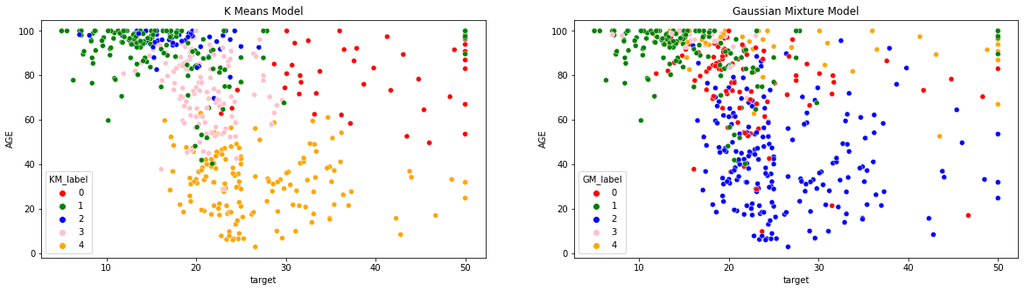

```python
# Visualizing the Clusters from both the Methods

plt.figure(figsize=(20,5))

# Plot from K Means
plt.subplot(1,2,1)
sns.scatterplot(df["target"], df["AGE"] , hue=df["KM_label"], palette = ['Red', 'Green','Blue','Pink','Orange'])
plt.title("K Means Model")

# Plot from GM Model
plt.subplot(1,2,2)
sns.scatterplot(df["target"], df["AGE"] , hue=df["GM_label"], palette = ['Red', 'Green','Blue','Pink','Orange'])
plt.title("Gaussian Mixture Model")
```

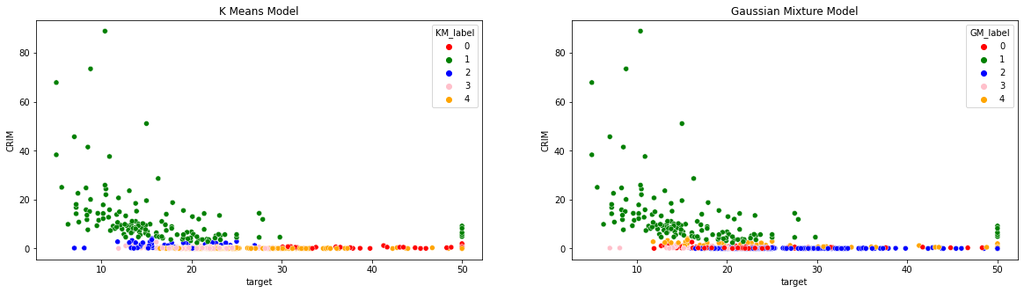

```python
plt.figure(figsize=(20,5))

# Plot from K Means
plt.subplot(1,2,1)
sns.scatterplot(df["target"], df["CRIM"] , hue=df["KM_label"], palette = ['Red', 'Green','Blue','Pink','Orange'])
plt.title("K Means Model")

# Plot from GM Model
plt.subplot(1,2,2)
sns.scatterplot(df["target"], df["CRIM"] , hue=df["GM_label"], palette = ['Red', 'Green','Blue','Pink','Orange'])
plt.title("Gaussian Mixture Model")
```

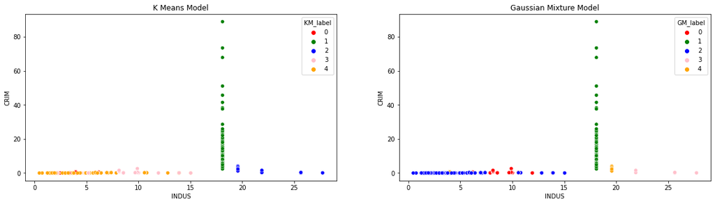

```python
plt.figure(figsize=(20,5))

# Plot from K Means
plt.subplot(1,2,1)
sns.scatterplot(df["INDUS"], df["CRIM"] , hue=df["KM_label"], palette = ['Red', 'Green','Blue','Pink','Orange'])
plt.title("K Means Model")

# Plot from GM Model
plt.subplot(1,2,2)
sns.scatterplot(df["INDUS"], df["CRIM"] , hue=df["GM_label"], palette = ['Red', 'Green','Blue','Pink','Orange'])
plt.title("Gaussian Mixture Model")
```

##### From the above graphs it seems that in comparing with some variables KMeans is segregating the clusters properly and in some cases Gaussian Mixtures separates the classes properly. Thus its quite difficult to decide among the two models. But seeing the ease of explanation of K Means Model we can use the K Means Model.

### Cluster Profiling

```python
# Comparing the Aggregate Tables from both the models
agg_KMeans = df.groupby('KM_label', as_index = False).agg({
    'target':['mean'],
    'CRIM' : ['mean'],
    'INDUS': ['mean'],
    'AGE': ['mean'],
    'RAD': ['mean'],
    'LSTAT': ['mean']
}).round(1)
agg_KMeans
```

|  | KM_label | target mean | CRIM mean | INDUS mean | AGE mean | RAD mean | LSTAT mean |
| --- | --- | --- | --- | --- | --- | --- | --- |
| 0 | 0 | 38.6 | 0.5 | 6.2 | 79.2 | 5.2 | 5.9 |
| 1 | 1 | 16.4 | 12.8 | 18.1 | 89.8 | 24.0 | 18.6 |
| 2 | 2 | 17.8 | 1.3 | 21.8 | 94.8 | 4.2 | 17.5 |
| 3 | 3 | 20.5 | 0.3 | 8.3 | 75.0 | 4.7 | 13.0 |
| 4 | 4 | 27.0 | 0.1 | 5.1 | 31.7 | 4.1 | 7.2 |

Cluster 1: a. High Priced | b. Low Crime Rate | c. Low Industrial Area | d. More proportion of homes built prior to 1940 | e. Good access to Highway | e. Lower % of lower status people |

Cluster 3: a. Low Priced | b. Low Crime Rate | c. High Industrial Area | d. Highest proportion of homes built prior to 1940 | e. Good access to highway | f. High % of lower status people |

Cluster 5: a. Medium to High Priced | b. Lowest Crime Rate | c. Low Industrial Area | d. Newly built properties and houses | e. Good access to highway | f. Low % of lower status people |